# Final Assignment R lessons

## Introduction

This is the final assignment of the intro lessons on R. You should work within this document, and “Knit” it into a Word document when you are finished. Submit the resulting Word document as well as this .Rmd document on Blackboard.

The presentation is available here: https://michielnoback.github.io/intro_R_lessons/Intro_lesson_1.html

This will include both the code and its result into the created document.  
Clicking the tiny green arrow in the top right corner of a code chunk will execute only that chunk, within RStudio.

## Load the data

Run this chunk to download the data and load it into your R session.

```r
protein_data <- read.table(file = "https://git.io/fjfMC",
                        header = TRUE,
                        sep = ";",
                        dec = ",",
                        as.is = c(1, 2, 3, 21))
```

## The assignments

#### Assignment 1

You have seen the function `table()` which can be used to create a frequency table. Apply this function to generate a table for the different localizations as identified by LipoP.

```r
table(protein_data$LipoP_Localisation)
```

```
##
##  CYT  SpI SpII  TMH
##  146   90   70   81
```

```r
##OR
table(protein_data[, 15])
```

```
##
##  CYT  SpI SpII  TMH
##  146   90   70   81
```

#### Assignment 2

Use `table()` again, this time to create a “contingency table” (cross tabulation) for LipoP localization agains SignalP predictions (Yes/No). Is there a (cor)relation between these analyses?

```r
table(protein_data$LipoP_Localisation, protein_data$SignalP_YesNo)
```

```
##
##          N   Y
##   CYT  146   0
##   SpI    8  82
##   SpII  18  52
##   TMH   81   0
```

#### Assignment 3

First run the chunk below to get a new column for the TMHMM analysis, giving a simplified version of column `TMHMM_PredHel`. If the number of transmembrane helices is bigger then 1, it is reduced to “2+”

```r
protein_data$TMHMM_PredHelSimple <- protein_data$TMHMM_PredHel
protein_data$TMHMM_PredHelSimple <- ifelse(protein_data$TMHMM_PredHel > 1, "2+", protein_data$TMHMM_PredHel)
```

Have a look at this new column.

Next, create a “contingency table” for SignalP against TMHMM_PredHelSimple predictions. Is there a (cor)relation between these analyses? What does this say?

```r
table(protein_data$SignalP_YesNo, protein_data$TMHMM_PredHelSimple)
```

```
##
##       0   1  2+
##   N 109  17 127
##   Y 104  30   0
```

#### Assignment 4

Find out how many proteins have a negative result in the three analyses (SignalP, LipoP, TMHMM). Negative means N (SignalP), CYT (LipoP) and 0 (TMHMM PredHel). Use `nrow()` on the resulting selection to get the number of cases.

Next, find out how many are negative for *all three* analyses Hint: use (combination of) logical selections: `condition_A & condition_B`

```r
nrow(protein_data[protein_data$SignalP_YesNo == "N", ])
nrow(protein_data[protein_data$LipoP_Localisation == "CYT", ])
nrow(protein_data[protein_data$TMHMM_PredHel == 0, ])

nrow(protein_data[protein_data$SignalP_YesNo == "N"
                  & protein_data$LipoP_Localisation == "CYT"
                  & protein_data$TMHMM_PredHel == 0, ])
```

```
## [1] 253
## [1] 146
## [1] 213
## [1] 101
```

```r
### ALTERNATIVE SOLUTION USING TRUE EQUALS 1 AND FALSE EQUALS 0
sum(protein_data$SignalP_YesNo == "N")
sum(protein_data$LipoP_Localisation == "CYT")
sum(protein_data$TMHMM_PredHel == 0)

sum(protein_data$SignalP_YesNo == "N"
                  & protein_data$LipoP_Localisation == "CYT"
                  & protein_data$TMHMM_PredHel == 0)
```

```
## [1] 253
## [1] 146
## [1] 213
## [1] 101
```

#### Assignment 5

Read the help page of the `summary()` function. Then, use this function and combine it with logical selection to find out what the mean, minimum and maximum values are of the LipoP score for the four different protein classes (CYT, SpI, SpII, TMH). Hint: select each subgroup in the dataframe using logical selection on the rows, and only the “LipoP_Score” column

```r
summary(protein_data$LipoP_Score[protein_data$LipoP_Localisation == "CYT"])
summary(protein_data$LipoP_Score[protein_data$LipoP_Localisation == "SpI"])
summary(protein_data$LipoP_Score[protein_data$LipoP_Localisation == "SpII"])
summary(protein_data$LipoP_Score[protein_data$LipoP_Localisation == "TMH"])
```

```
##    Min. 1st Qu.  Median    Mean 3rd Qu.    Max.
## -0.2009 -0.2009 -0.2009 -0.2009 -0.2009 -0.2009
##     Min.  1st Qu.   Median     Mean  3rd Qu.     Max.
##  0.00795  6.55896 10.58465 11.08779 14.87930 26.26240
##    Min. 1st Qu.  Median    Mean 3rd Qu.    Max.
##  0.1167 12.1608 17.7996 17.0658 22.0088 30.7315
##    Min. 1st Qu.  Median    Mean 3rd Qu.    Max.
##   0.182   4.690   7.487   8.089  11.544  17.233
```

#### Assignment 6

Create a scatter plot of SignalP_Smax versus LipoP_Score and give it nice axis labels.

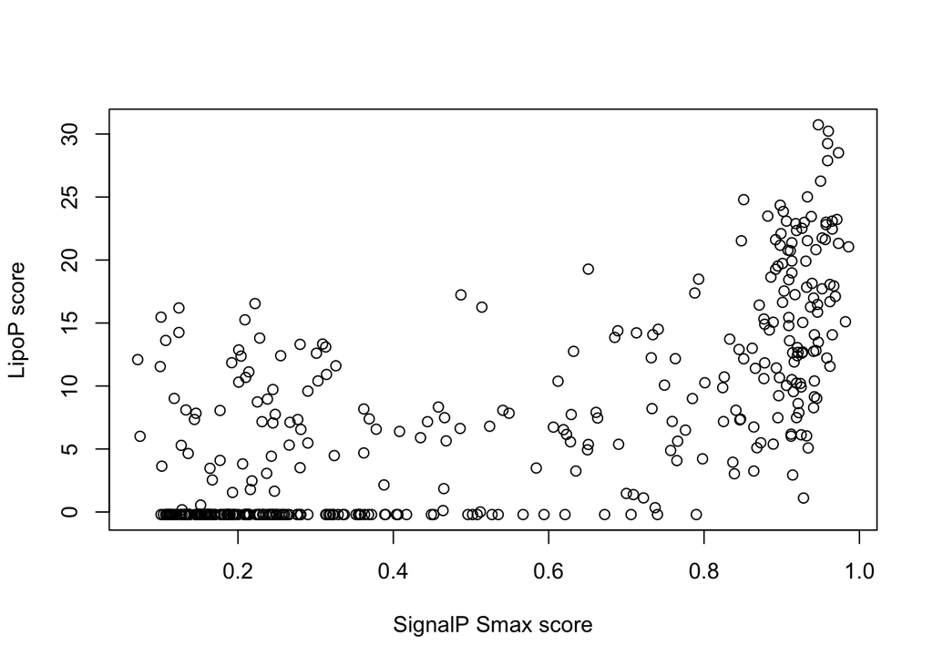

```r
plot(protein_data$SignalP_Smax, protein_data$LipoP_Score,
     xlab="SignalP Smax score", ylab="LipoP score")
```

#### Assignment 7

Study the help page of the `hist()` function. Create a histogram of the protein lengths. There are three large proteins that distort the image quite a lot. Try to exclude these and generate the histogram again, or try to use the `breaks` argument to get a better image.

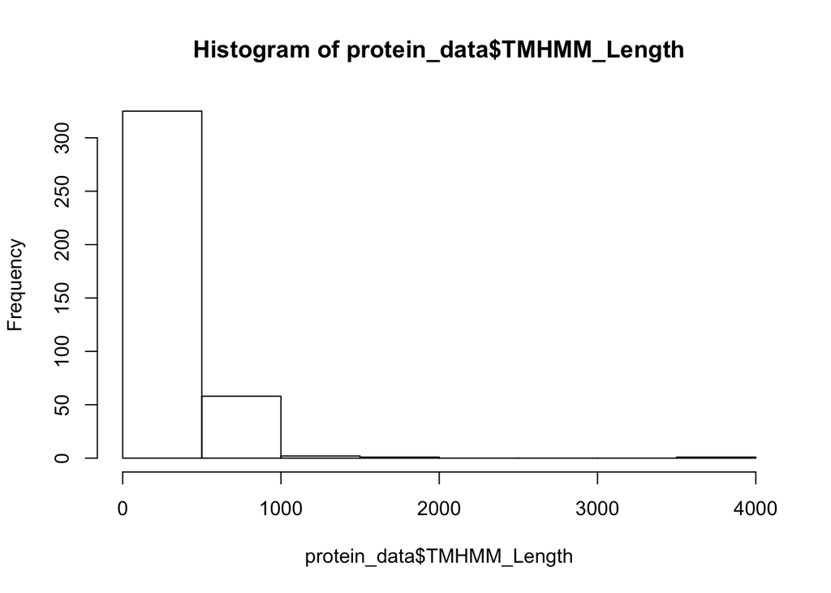

```r
#All
hist(protein_data$TMHMM_Length)
```

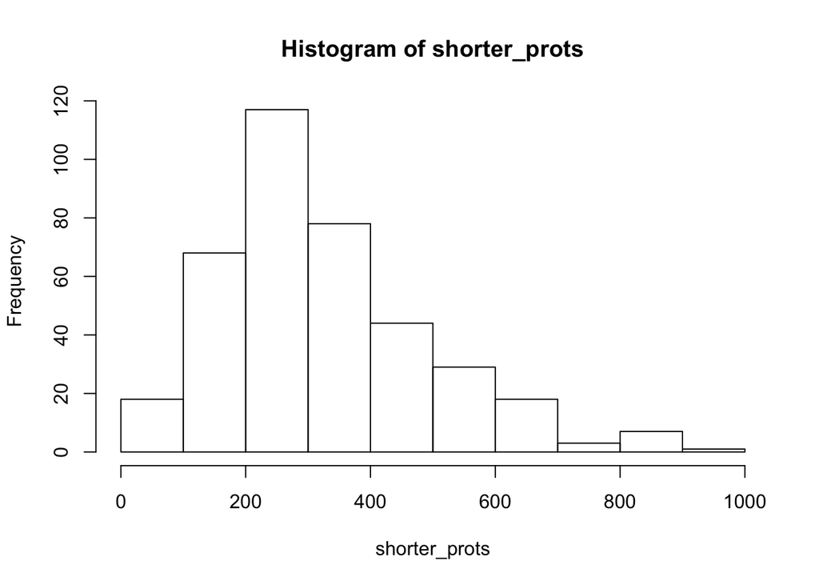

```r
#Exclude proteins over 1000 residues
shorter_prots <- protein_data$TMHMM_Length[protein_data$TMHMM_Length < 1000]
hist(shorter_prots)
```

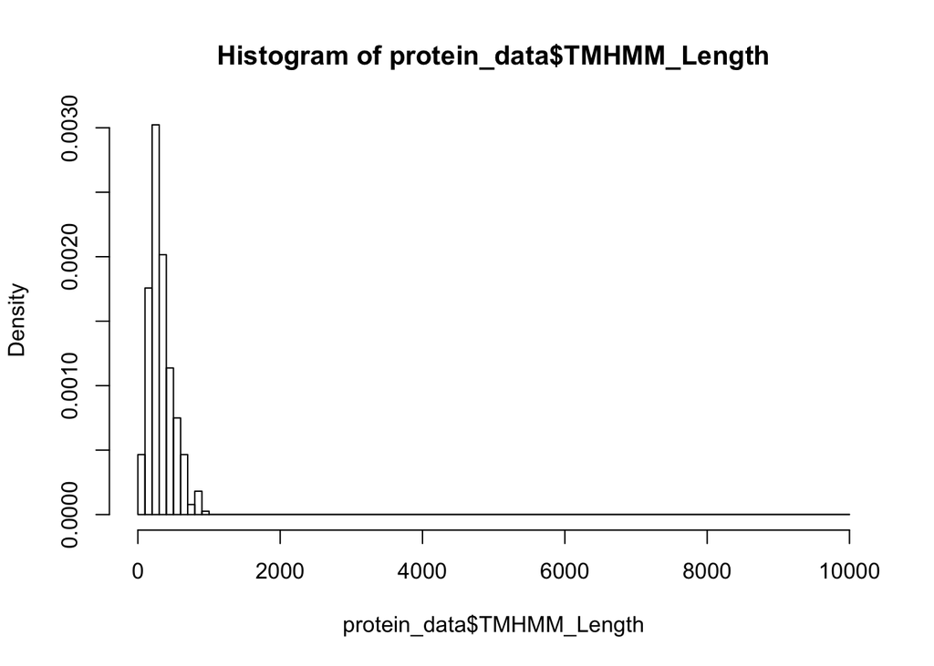

```r
#CHALLENGE: set the breaks attribute
hist(protein_data$TMHMM_Length, breaks=c(0, 100, 200, 300, 400, 500, 600, 700, 800, 900, 1000, 10000))
#BETTER:
hist(protein_data$TMHMM_Length, breaks=c(seq(from = 0, to = 1000, by = 100), 10000))
```

[output not shown]